# homework

Yann Dubois

3/1/2017

# Question 1

## 1.1 Download and inspect the data

First lets set up the environment: upload the data and useful packages.

```r
# Packages
library(limma)
library(edgeR)
library(data.table)
library(dplyr)
library(ggplot2)
library(plotly)
library(car)
library(lattice)

# makes everything reproductible
set.seed(1234)

# Stores the data in Data table (better for large files)
transData <- read.table("Data/NHBE_transcriptome_data.txt", sep="\t", header=TRUE, row.names = 1)
designMat <- read.table("Data/NHBE_design.txt", sep="\t", header=TRUE, row.names = 1)

prepareData <- function(myGenes) {
    miniDat <- t(transData[myGenes, ])
    miniDat <- suppressWarnings(data.frame(gExp = as.vector(miniDat),
                          gene = rep(colnames(miniDat), each = nrow(miniDat))))
    miniDat <- suppressWarnings(data.frame(designMat, miniDat))
    miniDat
}
```

```r
str(transData)
```

```
## 'data.frame':    22737 obs. of  23 variables:
##  $ GSE10718_Biomat_1 : num  7.9 6.13 6.82 6.63 6.95 ...
##  $ GSE10718_Biomat_10: num  7.62 5.85 7.62 5.7 7.51 ...
##  $ GSE10718_Biomat_11: num  8.22 6.3 7.22 6.22 7.29 ...
##  $ GSE10718_Biomat_12: num  8.01 5.91 6.17 6.06 7.95 ...
##  $ GSE10718_Biomat_13: num  7.61 6.62 7.2 6.89 7.87 ...
##  $ GSE10718_Biomat_14: num  7.45 6.82 7.4 7.02 7.55 ...
##  $ GSE10718_Biomat_15: num  7.41 6.88 6.78 6.59 7.27 ...
##  $ GSE10718_Biomat_16: num  7.67 6.83 6.99 6.45 7.56 ...
##  $ GSE10718_Biomat_17: num  7.89 6.45 5.85 6.18 7.24 ...
##  $ GSE10718_Biomat_19: num  7.8 6.66 6.83 6.19 6.96 ...
##  $ GSE10718_Biomat_2 : num  7.72 6.57 6.67 6.74 7.05 ...
##  $ GSE10718_Biomat_20: num  7.55 5.81 6.28 5.57 8.04 ...
##  $ GSE10718_Biomat_21: num  6.34 7.06 7.23 5.77 7.62 ...
##  $ GSE10718_Biomat_22: num  7.8 6.49 6.75 5.59 7.32 ...
##  $ GSE10718_Biomat_23: num  7.95 7.08 7.11 7.14 7.83 ...
##  $ GSE10718_Biomat_24: num  7.88 6.24 6.97 6.34 7.03 ...
##  $ GSE10718_Biomat_3 : num  7.51 6.38 6.98 6.73 7.06 ...
##  $ GSE10718_Biomat_4 : num  7.31 6.89 7.62 6.48 8.46 ...
##  $ GSE10718_Biomat_5 : num  8 7.1 7.29 5.72 7.73 ...
##  $ GSE10718_Biomat_6 : num  7.5 6.42 7.68 6.28 7.54 ...
##  $ GSE10718_Biomat_7 : num  7.5 6.27 7.12 6.63 8.17 ...
##  $ GSE10718_Biomat_8 : num  7.51 6.53 6.61 6.52 7.67 ...
##  $ GSE10718_Biomat_9 : num  7.74 6.89 6.71 7.06 7.42 ...
```

```r
show(designMat)
```

```
##                    ExternalID       Treatment time
## GSE10718_Biomat_1   GSM270883         control 24_h
## GSE10718_Biomat_10  GSM270874         control  1_h
## GSE10718_Biomat_11  GSM270873         control  1_h
## GSE10718_Biomat_12  GSM270872         control  1_h
## GSE10718_Biomat_13  GSM270881         control  4_h
## GSE10718_Biomat_14  GSM270880         control  4_h
## GSE10718_Biomat_15  GSM270879         control  4_h
## GSE10718_Biomat_16  GSM270887 cigarette_smoke  1_h
## GSE10718_Biomat_17  GSM270886 cigarette_smoke  1_h
## GSE10718_Biomat_19  GSM270889 cigarette_smoke  2_h
## GSE10718_Biomat_2   GSM270882         control 24_h
## GSE10718_Biomat_20  GSM270888 cigarette_smoke  2_h
## GSE10718_Biomat_21  GSM270890 cigarette_smoke  2_h
## GSE10718_Biomat_22  GSM270891 cigarette_smoke  4_h
## GSE10718_Biomat_23  GSM270892 cigarette_smoke  4_h
## GSE10718_Biomat_24  GSM270893 cigarette_smoke  4_h
## GSE10718_Biomat_3   GSM270884         control 24_h
## GSE10718_Biomat_4   GSM270894 cigarette_smoke 24_h
## GSE10718_Biomat_5   GSM270895 cigarette_smoke 24_h
## GSE10718_Biomat_6   GSM270896 cigarette_smoke 24_h
## GSE10718_Biomat_7   GSM270878         control  2_h
## GSE10718_Biomat_8   GSM270876         control  2_h
## GSE10718_Biomat_9   GSM270875         control  2_h
```

```r
if(all(rownames(designMat) == colnames(transData))) {print("The design matrix and data agree")}
```

```
## [1] "The design matrix and data agree"
```

```r
if (!anyNA(transData)) { print("There are no missing values in transData") }
```

```
## [1] "There are no missing values in transData"
```

**The dataset contains the expression of:**

- 22737 genes
- 23 samples. For each 2*4=8 types of treatments, there are therefore 3 samples (one “cigarette_smoke” “1_h” is missing ).

**The different samples are :**

- Treatment: cigarette_smoke, control. i.e. If the cell was exposed to smoke or air (“mock control”).
- time: 1_h, 2_h, 24_h, 4_h. i.e. The time after which the transcriptome alterations were assessed using micro-arrays.

## 1.2 Basic data manipulation

Adds a quantitative variable for time in the design matrix.

```r
designMat$timeCont <- car::recode(designMat$time,
                         "'1_h'=1; '2_h'=2; '4_h'=4; '24_h'=24",
                         as.factor.result = FALSE)
```

## 1.3 Basic graphing

First lets plot all in a signle graph.

```r
randomRowNumber <- sample(1:nrow(transData), 1)
randomGeneName <- rownames(transData)[[randomRowNumber]]
# aggregates the meta data and data, using the function coded above
randGene <- prepareData(randomGeneName)
plotRandGene <- ggplot(randGene,aes(x=Treatment,y=gExp,color=factor(timeCont)))+
  geom_point(aes(stroke=1.3)) +
  theme_minimal() +
  stat_summary(fun.y = "mean", aes(colour = "mean"), size = 3, geom="point", shape=3) +
  scale_color_manual("Time since exposure (hours)", values = c("1"="#e31a1c","2"="#fd8d3c","4"="#fecc5c","24"="#ffffb2","mean"="black")) +
  ggtitle("Differential expression due to tabacco") +
  ylab("Gene expression (relative)")

ggplotly(plotRandGene)
```

[interactive chart not shown]

We could also decide to use different facets. It is easier to compare the effect of treatments at each time point, but harder to compare between time points.

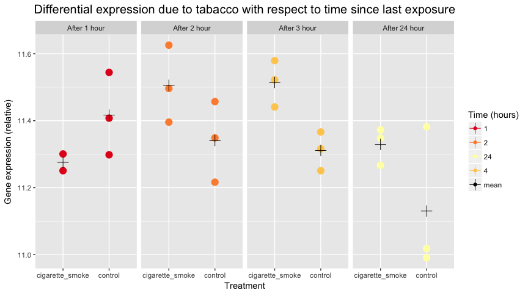

```r
label_names <- c(
                    "1" = "After 1 hour",
                    "2" = "After 2 hour",
                    "4" = "After 3 hour",
                    "24" = "After 24 hour"
                    )

ggplot(randGene,aes(x=Treatment,y=gExp,color=factor(timeCont)))+
  geom_point(aes(stroke=2.1)) +
  stat_summary(fun.y = "mean", aes(colour = "mean"), size = 4, geom="point", shape=3) +
  scale_color_manual("Time (hours)", values = c("1"="#e31a1c","2"="#fd8d3c","4"="#fecc5c","24"="#ffffb2","mean"="black")) +
  ggtitle("Differential expression due to tabacco with respect to time since last exposure") +
  theme(plot.title = element_text(hjust = 0.5, size = 15)) +
  facet_wrap(~ timeCont, ncol = 4, labeller=as_labeller(label_names)) +
  ylab("Gene expression (relative)")
```

*Note*: For both plots I’ve written that the gene expression is in a relative unit. In reality they represent log2 normalized fluorescence intensity values which is unitless.

# Question 2

## 2.1 Examine the sample-to-sample correlations in a heatmap

*Note:* In both heat maps below, I decided to take out the diagonal as it will always be filled with ones. This enables us to have a more informative color gradient.

```r
# function that will be used to extract the last 2 digits of ExternalID
substrRight <- function(x){
  c <- as.character(x)
  substr(c, nchar(c)-1, nchar(c))
}

# REORDERING
# here orders by time first and then treatment
indexTimeTreatment <- order(designMat$timeCont, designMat$Treatment)
designTimeTreatment <- designMat[indexTimeTreatment,]
sampleNameTimeTreatment <- rownames(designTimeTreatment)

correlationTimeTreatment <- cor(transData[,sampleNameTimeTreatment])
treatmentShort <- as.character(designTimeTreatment$Treatment)
treatmentShort <- replace(treatmentShort,treatmentShort=="cigarette_smoke","smoke")
niceLabelTimeTreatment <- paste(designTimeTreatment$time, treatmentShort, substrRight(designTimeTreatment$ExternalID))
# sets the diagonal to empty because will always be 1 and want to be able to see
# small differences between other samples
diag(correlationTimeTreatment) = NA

m <- list(l=150, r=50, b=150, t=60, pad=4)
# needs to force the non-alphabetical ordering
xylabTimeTreatment = list(categoryorder = "array", categoryarray = niceLabelTimeTreatment)
plot_ly(x = niceLabelTimeTreatment, y=niceLabelTimeTreatment, z = ~correlationTimeTreatment, type = "heatmap", colorscale = "Greys") %>%
  layout(title = 'Correlation heatmap: ordering by time and then treatment', margin=m,xaxis = xylabTimeTreatment, yaxis = xylabTimeTreatment)
```

[interactive chart not shown]

```r
# REORDERING
# here orders by treatment first and then by time
indexTreatmentTime <- order(designMat$Treatment, designMat$timeCont)
designTreatmentTime <- designMat[indexTreatmentTime,]
sampleNameTreatmentTime <- rownames(designTreatmentTime)

correlationTreatmentTime <- cor(transData[,sampleNameTreatmentTime])
treatmentShort <- as.character(designTreatmentTime$Treatment)
treatmentShort <- replace(treatmentShort,treatmentShort=="cigarette_smoke","smoke")
niceLabelTreatmentTime <- paste(designTreatmentTime$time, treatmentShort, substrRight(designTreatmentTime$ExternalID))
# sets the diagonal to empty because will always be 1 and want to be able to see
# small differences between other samples
diag(correlationTreatmentTime) = NA

m <- list(l=150, r=50, b=150, t=60, pad=4)
# needs to force the non-alphabetical ordering
xylabTreatmentTime = list(categoryorder = "array", categoryarray = niceLabelTreatmentTime)
plot_ly(x = niceLabelTreatmentTime, y=niceLabelTreatmentTime, z = ~correlationTreatmentTime, type = "heatmap", colorscale = "Greys") %>%
  layout(title = 'Correlation heatmap: ordering by treatment and then time', margin=m,xaxis = xylabTreatmentTime, yaxis = xylabTreatmentTime)
```

[interactive chart not shown]

We see that every coorelation result is very high: approximatively between [0.88,0.94]. This high correlation is not very suprising as it means that when a gene is relatively highly expressed, it will be relatively highly expressed in every sample. To be more precise (default correlation in R is pearson) the gene expression in different samples are close to **linearly dependant** (with a positive slope). This very probably due to a confounding variable, which is simply the mean expression of a gene.

## 2.2 Assess the presence of outlier samples

One intersting information that we can catch sight of quickly, is the fact that “1_h control 74” has a very low correlation with all other genes. This could indicate a possible problem with that sample (outlier). We can also see 2 other samples that have a low overall correlation with other samples (“24_h smoke 94” and “24_h smoke 95”). Inspite of their low correlations with other samples, they seem to be highly correlated bewtween them and with the third 24_h sample : “24_h smoke 96”. This indicates that contrary to the the first “outlier” we decribed (which could be simply an error), these 2 seem very interesting! On the second heatmap we also realize that sample “24_h smoke 96” seems suprisingly highly correlated with every other sample. It could be interesting to keep that sample in mind and maybe also test its outlierness.

To look more closely at the outlierness of these samples, let’s have a look at the kernel density plot:

*Note* I’m keeping the diagonal empty as what were are interested in as it will always be 1 and does not give any valuable information! Keeping it could indeed increas the the number of false negative uselessly for smaller number of samples (shouldn’t change anything for 23).

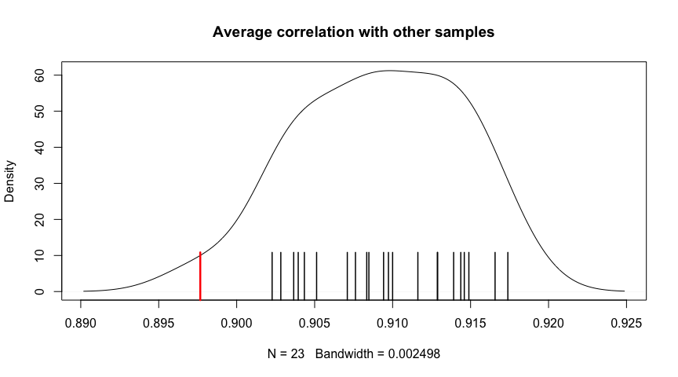

```r
# plots kernel density
correlationMeans <- rowMeans(correlationTreatmentTime, na.rm = TRUE)
plot(density(correlationMeans),
  main = "Average correlation with other samples")
rug(correlationMeans, lwd = 1.5, ticksize = 0.2)
rug(min(correlationMeans), col = "red", lwd = 2.5, ticksize = 0.2)
```

On the density plot we do see that one of the samples (“1_h control 74”) could be an outlier, although it doesn’t seem shocking enough to remove it.

*Note:* Here we a only comparing the mean correlation of the sample to the average *total* mean correlation. This gives doesn’t take into account an important information which is that the sample are grouped by 3 (or 2). Let’s look also plot the groups:

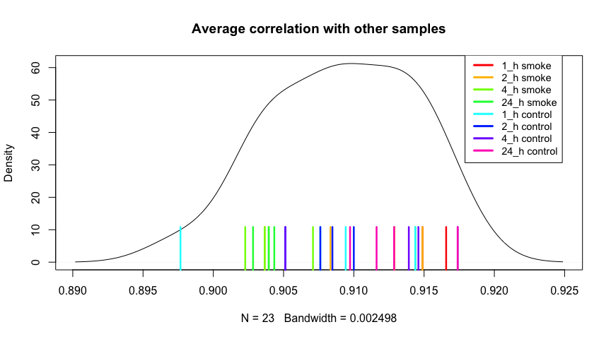

```r
niceLabelNoId <- unique(paste(designTreatmentTime$time, treatmentShort))
# plots kernel density
plot(density(correlationMeans),
  main = "Average correlation with other samples")
iOld = 1
k=1
for (i in seq(from = 2, to = 23, by = 3)) {
  # plots ticks by group
  rug(correlationMeans[iOld:i], col = rainbow(8)[k], lwd = 2.5, ticksize = 0.2)
  iOld = i
  # color counter
  k=k+1
}
# adds manual legen
par(new=TRUE)
plot(1, type="n", axes=FALSE, xlab="", ylab="")
legend(1, 1, legend = niceLabelNoId, col=rainbow(8),lwd=3, cex=0.9, xjust=-1.5, yjust=0)
```

This plot is very interesting because we now see the group and population correlation average. Now sample (“1_h control 74”) seems very likely to be an outlier as it is very different from the 2 other “1_h control” samples.

To test these hypothesis quantitatively (although not taking into account the group average: see other techniques for better methods that would take it into account). Let’s compute a t-test to compare the sample which could be an utlier with all other samples.

*Note:* We have to use *var.equal = T* (not Welch test) because we cannot compute $s_x$ as the sample size is of 1. But this assumption of equal variance seems plausible as it would be the expression variance of every cell in our body. Note that with this t-test we assume that identically distributed, which is not true as we know that there are sub groups. This should be better taken into account using for example bayesian models (see below).

```r
alpha = 0.95
for (i in c(1:23)){
  testOutlierT <- t.test(correlationMeans[i],correlationMeans, alternatives = "two.sided", conf.level = alpha, var.equal = T)
  # if 0 is not in confidence interval
  if(sign(testOutlierT$conf.int[1])  == sign(testOutlierT$conf.int[2])){
    print(paste(niceLabelTreatmentTime[i], "is significantly different from the others, withp-value=", testOutlierT$p.value))
  }
}
```

```
## [1] "1_h control 74 is significantly different from the others, withp-value= 0.0421846532518661"
```

We therefore see that even if we don not take into account the multiple groups (which would make “1_h control 74” even mor outlier) it is already an outlier.

Other techniques that I could have used:

- Assume that each sample lives in a 23 dimensional world (one dimension for the correlation with each other sample) and that it is sampled by a multivariate gaussian. So we could fit a multivariate gaussian and compute the probability that each sample comes from that distribution. A sample would be considered as an outlier if it’s probability under the multivariate gaussian is beneath a threshold. Problem: gaussian distribution is not robust to outliers. This distribution would not take into account the fact that that there are 8 sub-goups that should be very similar.
- Use a dimensionality reduction algorithm and “see” if there are outliers. Ex: t-sne or PCA. Problem: PCA is based on squarred error and is thus not robust. T-SNE could be a good idea! These 2 methods would still not take into account the fact that that there are 8 sub-goups that should be very similar.
- Fit a empirical bayesian hierarchical model whith parameters $\phi$ and $\theta$ where we can assume conditional independance such that $p(sample = x | \phi , \theta) = p(sample=x|\theta)p(\theta|\phi)p(\phi)$. With $\theta$ the parameter of the group of samples (8 groups: same treatment and same “time”). $\phi$ the parameter of the distribution of all the samples. Finally compute the probability under these priors. This would probably be the best way if we use a robust distribution such as the laplace or t distribtuion.

# Question 3

## 3.1 Linear model

```r
desTreatment <- model.matrix(~Treatment, designMat)
fitTreatment <- lmFit(transData, desTreatment )
fitTreatmentEb <- eBayes(fitTreatment)
ttTreatment <- topTable(fitTreatmentEb)
```

```
## Removing intercept from test coefficients
```

```r
show(ttTreatment)
```

```
##                  logFC   AveExpr         t      P.Value    adj.P.Val
## 200779_at   -0.7613410 13.983184 -8.577428 1.419183e-08 0.0001750755
## 202912_at   -1.7199499 12.764302 -8.161121 3.365296e-08 0.0001750755
## 214696_at   -1.9074941 11.730937 -8.155234 3.407195e-08 0.0001750755
## 223394_at   -1.2644771 10.909886 -8.147206 3.465212e-08 0.0001750755
## 223774_at   -1.1696606  9.529931 -8.080341 3.989741e-08 0.0001750755
## 209020_at   -1.0223766 10.677979 -7.939997 5.373691e-08 0.0001750755
## 202672_s_at -3.5302487  9.716310 -7.904577 5.795528e-08 0.0001750755
## 220468_at   -2.4132680  6.488711 -7.876047 6.160022e-08 0.0001750755
## 223982_s_at -0.9256205 10.907060 -7.729633 8.438527e-08 0.0001933190
## 226924_at   -0.6366539  9.588851 -7.726141 8.502396e-08 0.0001933190
##                    B
## 200779_at   9.623149
## 202912_at   8.840436
## 214696_at   8.829176
## 223394_at   8.813808
## 223774_at   8.685431
## 209020_at   8.413709
## 202672_s_at 8.344646
## 220468_at   8.288875
## 223982_s_at 8.000666
## 226924_at   7.993752
```

I decided to use the $ref + effect$ model and not the cell means because I find that the p–value computed is the more natural one. In plain english : the model I’m fitting is taking the reference as “cigarette_smoke”. So all the expression values are first modelled by the mean of the “cigarette_smoke” samples. It then substracts a parameter only for “control” variables. These 2 parameters give us the model, the difference with the given expression value is the residue $\epsilon$. The linear model is fitted by minimizing $\epsilon$ (computing and finding it’s minimum by equalizing the derivative to 0).

In more mathy way here is the model fitted:
$$Y_{ij} = \theta + \tau_j + \epsilon_{ij}$$
which can be written in matrix form
$$\begin{align*}
y&=X \alpha + \epsilon \\
\left( \begin{matrix}
y_{11}\\
\vdots\\
y_{n1}\\
y_{12}\\
\vdots\\
y_{n2} \end{matrix} \right)
&=
\left( \begin{matrix}
1 & 0\\
\vdots & \vdots \\
1 & 0 \\
1 & 1\\
\vdots & \vdots \\
1 & 1 \end{matrix} \right)
*
\left( \begin{matrix}
mean\_smoke \\
\delta_{control - smoke} \end{matrix} \right)
+
\left( \begin{matrix}
\epsilon_{11}\\
\vdots\\
\epsilon_{n1}\\
\epsilon_{12}\\
\vdots\\
\epsilon_{n2} \end{matrix} \right)
\end{align*}$$

Here the adjusted p-value therefore tests if the expression difference between “smoke” samples and “control” samples is statistically significant. i.e: The null hypothesis $H0$ is that the mean of control samples and smoke samples is the same. The adjusted p-value use the Benjamin and Hocberg method to adjust the p-value (important beacsue of the huge number of tests). It therefore gives the proprtion of false positives we are expected to get if we call this feature significant (i.e. targets **FDR**).

## 3.2 Look at the hits

```r
cutoffP <- 1e-03
cutoffPadj <- 0.05

numhitsTreatment <- nrow(topTable(fitTreatmentEb, p.value = cutoffP, n = Inf, adjust.method="none"))
```

```
## Removing intercept from test coefficients
```

```r
numBHhitsTreatment <- nrow(topTable(fitTreatmentEb, p.value = cutoffPadj, n = Inf))
```

```
## Removing intercept from test coefficients
```

There are 805 probes with p-values smaller than 0.001. While there are 1238 probes with adjusted p-values smaller than 0.05.

```r
nHit = 50
hitsTreatment <- topTable(fitTreatmentEb, n = nHit)
```

```
## Removing intercept from test coefficients
```

```r
hitNames <- rev(rownames(hitsTreatment))
gExpression <- as.matrix(transData[hitNames,sampleNameTreatmentTime])

m <- list(l=150, r=50, b=150, t=60, pad=4)
# needs to force the non-alphabetical ordering
xlabHits = list(categoryorder = "array", categoryarray = niceLabelTreatmentTime)
ylabHits = list(categoryorder = "array", categoryarray = hitNames)
plot_ly( x=niceLabelTreatmentTime , y=~hitNames ,z = ~gExpression, type = "heatmap", colorscale = "Greys") %>%
  layout(title = 'Correlation heatmap: ordering by treatment and then time', margin=m,xaxis = xlabHits, yaxis = ylabHits)
```

[interactive chart not shown]

By definition $FDR = \frac{F}{S}$ so $F=S*FDR$. Where $FDR$ is the False Discovery Rate threshold used (i.e the max FDR of the hits). $S$ is number of significant gene which we can estimate by simply using the number of genes with $p-value \leq t$.

```r
FDRhit <- max(hitsTreatment$adj.P.Val)
estimatedF = nHit * FDRhit
```

We therefore conclude that the estimated false discovery rate is 0.001036 and that the number of false positives in our 50 hits is 0.0517996.

# Question 4

## 4.1 Linear model

```r
# use time as quantitative covariate
desTime <- model.matrix(~timeCont, designMat)
fitTime <- lmFit(transData, desTime )
fitTimeEb <- eBayes(fitTime)
ttTime <- topTable(fitTimeEb)
```

```
## Removing intercept from test coefficients
```

```r
show(ttTime)
```

```
##                   logFC   AveExpr          t      P.Value    adj.P.Val
## 202586_at   -0.04321190  9.045753 -11.559699 5.595299e-11 1.272203e-06
## 203201_at   -0.04242793 10.057592 -10.121063 7.109181e-10 6.663751e-06
## 227559_at   -0.05501598  8.182478  -9.958972 9.609875e-10 6.663751e-06
## 202769_at    0.04317888 12.095002   9.769107 1.373425e-09 6.663751e-06
## 226775_at   -0.03828553  8.647287  -9.734894 1.465398e-09 6.663751e-06
## 213113_s_at -0.04650788 10.391574  -9.412004 2.721027e-09 1.031133e-05
## 202770_s_at  0.03591883 11.510308   9.272069 3.572582e-09 1.160426e-05
## 226226_at    0.04323136  9.561381   9.139895 4.630899e-09 1.316159e-05
## 202887_s_at  0.04197944 13.601392   8.972788 6.449452e-09 1.629347e-05
## 200810_s_at -0.03436033 11.350772  -8.828058 8.617559e-09 1.674623e-05
##                    B
## 202586_at   15.28331
## 203201_at   12.74567
## 227559_at   12.44384
## 202769_at   12.08602
## 226775_at   12.02105
## 213113_s_at 11.40035
## 202770_s_at 11.12709
## 226226_at   10.86660
## 202887_s_at 10.53391
## 200810_s_at 10.24274
```

```r
numhitsTime <- nrow(topTable(fitTimeEb, p.value = cutoffP, n = Inf, adjust.method="none"))
```

```
## Removing intercept from test coefficients
```

```r
numBHhitsTime <- nrow(topTable(fitTimeEb, p.value = cutoffPadj, n = Inf))
```

```
## Removing intercept from test coefficients
```

There are 958 probes with p-values smaller than 0.001. While there are 1451 probes with adjusted p-values smaller than 0.05.

# Question 5

## 5.1 Quantify the number of hits for treatment

```r
# use time as quantitative covariate
desTimeTreatment <- model.matrix(~timeCont*Treatment, designMat)
fitTimeTreatment <- lmFit(transData, desTimeTreatment )
fitTimeTreatmentEb <- eBayes(fitTimeTreatment)
ttTimeTreatment <- topTable(fitTimeTreatmentEb)
```

```
## Removing intercept from test coefficients
```

```r
show(ttTimeTreatment)
```

```
##                timeCont Treatmentcontrol timeCont.Treatmentcontrol
## 214290_s_at  0.09410100      -0.16551666               -0.07394082
## 202870_s_at -0.08934809       0.22069666                0.06287376
## 208955_at   -0.06812775      -0.17577142                0.05748477
## 203108_at    0.08038465       0.59479660               -0.11407096
## 218542_at   -0.06617139       0.09262906                0.05928858
## 212281_s_at -0.06795005      -0.13169137                0.04787848
## 202954_at   -0.08021917      -0.06430425                0.06099165
## 225687_at   -0.06742085      -0.01686898                0.06235953
## 202779_s_at -0.06825002       0.01796472                0.04901065
## 203764_at   -0.08326001      -0.08054327                0.08864904
##              AveExpr         F      P.Value    adj.P.Val
## 214290_s_at 12.36283 156.55408 2.659658e-14 6.047264e-10
## 202870_s_at 11.80425 133.84586 1.230797e-13 1.399232e-09
## 208955_at   10.09237 123.82646 2.621916e-13 1.987150e-09
## 203108_at   12.71756 101.30302 1.817024e-12 1.032842e-08
## 218542_at   11.21883  90.07826 5.573399e-12 2.534448e-08
## 212281_s_at 10.96036  86.82289 7.903859e-12 2.782995e-08
## 202954_at   11.74982  86.08671 8.567956e-12 2.782995e-08
## 225687_at   11.25114  84.17688 1.059449e-11 3.011088e-08
## 202779_s_at 12.15344  74.95279 3.157967e-11 7.978077e-08
## 203764_at   10.82074  73.08677 3.997812e-11 9.089826e-08
```

```r
numhitsTimeTreatment <- nrow(topTable(fitTimeTreatmentEb, p.value = cutoffP, n = Inf, adjust.method="none", coef = "Treatmentcontrol"))
numBHhitsTimeTreatment <- nrow(topTable(fitTimeTreatmentEb, p.value = cutoffPadj, n = Inf, coef = "Treatmentcontrol"))
```

There are 621 probes with p-values smaller than 0.001. While there are 768 probes with adjusted p-values smaller than 0.05. This means that there are now 184 less probes with unadjusted p-value smaller than 0.001. While there are 470 less probes with adjusted p-values smaller than 0.05. This is because we are now controlling for the interaction between Time and Treatment. One mathematical way to understand it is that we added parameters because the model has now 4 parameters (before it had 2), some variance that was explained by the Treatment parameter is now explained by the Time and /or Time-Treatment interaction parameter. The treatment has therefore less weight! Note: there are also hits that were not present when cosidering only the Treatment but are present now, the reason behind it has to do with variance. Indeed, by adding new parameters we incereased the number of explained variance (i.e we decreased the residue $\epsilon$) this is easy to understand as the parameters were found to minimize $\epsilon$, so if it didn’t decrease the parameters would have been put to 0. By decreasing the variance it means that some variables that “were closed to be significative” before can become significative.

```r
namesHitTreatment <- rownames(topTable(fitTreatmentEb, p.value = cutoffP, n = Inf, adjust.method="none", coef = "Treatmentcontrol"))
namesHitTimeTreatment <- rownames(topTable(fitTimeTreatmentEb, p.value = cutoffP, n = Inf, adjust.method="none", coef = "Treatmentcontrol"))
nOverlap <- length(intersect(namesHitTreatment,namesHitTimeTreatment))
length(setdiff(namesHitTimeTreatment,namesHitTreatment))
```

```
## [1] 293
```

```r
length(setdiff(namesHitTreatment,namesHitTimeTreatment))
```

```
## [1] 477
```

There are 328 overlaping probes, which represents 52.8180354 % of the probes now that we control the interaction variable.

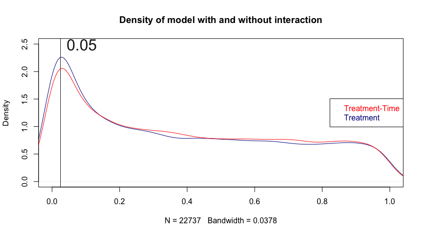

```r
pValueTreatment <- topTable(fitTreatmentEb, n = Inf, coef = "Treatmentcontrol")$P.Value
pValueTreatmentTime <- topTable(fitTimeTreatmentEb, n = Inf,  coef = "Treatmentcontrol")$P.Value

plot(density(pValueTreatment), xlim=c(0.0,1), ylim=c(0.0,2.5), main="Density of model with and without interaction",col="darkblue"); par(new=TRUE); plot(density(pValueTreatmentTime),axes=FALSE, xlab='', ylab='', xlim=c(0.0,1), ylim=c(0.0,2.5), main="",col="red1"); legend("right", legend = c("Treatment-Time","Treatment"),text.col=c("red1","darkblue")); abline(v = 0.025, col = "gray10"); text(0.025,2.37, "0.05", col = "gray10", adj = c(-.2, -.1), cex=2)
```

Not suprisingly we see that the distribution of the P-value is very close for both models. We are also happy to see a spike around $\alpha = 0.025$ which shows that the p-values are not unifromaly distributed. This would be the case if $H0$ were true.

## 5.2 Test the null hypothesis

With the interaction model we are adding the term $effect\_smoke*time$, which means that we are hypothesizing that the difference between gene expression of “smoke” and “control” samples change significantly when varying the time. One possible example might be that expression of “control” samples is always constant, while “smoke” samples start with the same expression (no effect yet) then change the expression (effect of tobacco on cells) and finally goes back to the “control” expression (effect disapears with time).

```r
numhitsTimeTreatmentInteraction <- nrow(topTable(fitTimeTreatmentEb, p.value = cutoffP, n = Inf, adjust.method="none", coef = "timeCont:Treatmentcontrol"))
numBHhitsTimeTreatmentInteraction <- nrow(topTable(fitTimeTreatmentEb, p.value = cutoffPadj, n = Inf, coef = "timeCont:Treatmentcontrol"))
```

There are 573 probes with p-values smaller than 0.001. While there are 664 probes with adjusted p-values smaller than 0.05.

## 5.3 Plot a few probes where the interaction does and does not matter

With the interaction model we are adding the term $effect\_smoke*time$, which means that we are hypothesizing that the difference between gene expression of “smoke” and “control” samples change significantly when varying the time. One possible example might be that expression of “control” samples is always constant, while “smoke” samples start with the same expression (no effect yet) then change the expression (effect of tobacco on cells) and finally goes back to the “control” expression (effect disapears with time).

```r
nameInteracHit <- rownames(topTable(fitTimeTreatmentEb, n = 4, sort.by = "p", coef = "timeCont:Treatmentcontrol"))
nameNoInteracHit <- rev(rownames(topTable(fitTimeTreatmentEb, n = Inf, sort.by = "P", coef = "timeCont:Treatmentcontrol")))[1:4]
dataInterac <- prepareData(nameInteracHit)
dataNoInterac <- prepareData(nameNoInteracHit)

gplotInterac <- ggplot(dataInterac, aes(x=timeCont,y=gExp,color=Treatment)) +
  geom_point() +
  facet_wrap(~ gene, ncol = 4) +
  geom_smooth(method='lm', se=F) +
  ggtitle("Interaction between treatment and time")

ggplotly(gplotInterac)
```

[interactive chart not shown]

```r
gplotNoInterac <- ggplot(dataNoInterac, aes(x=timeCont,y=gExp,color=Treatment)) +
  geom_point() +
  facet_wrap(~ gene, ncol = 4) +
  geom_smooth(method='lm', se=F) +
  ggtitle("Interaction between treatment and time")

ggplotly(gplotNoInterac)
```

[interactive chart not shown]

*Note*: I’ve plotted the plots above with a continuous time, as the model was made using a continuous time variable.